# Predicting Housing Prices - Linear Regression

*Data cleaning performed in accompanying Python notebook*

## Section 1: choosing 10 predictors

**Columns removed:**

**id**: Numbers have no other meaning outside of unit identification

**view**: Just because someone viewed house, doesn’t mean he would like it more

**zipcode**: big / small does not mean better; just an ID number

**lat**: bigger or smaller doesn’t mean better

**long**: bigger or smaller doesn’t mean better

**sqft_living15**: useless for 2014 houses

**sqft_lot15**: useless for 2014 houses

**yr_renovated**: many are blank if never renovated

**sqft_basement**: not as important as other parts of house; could be blank if no basement

Building a model with top 10 predictors using forward selection:

```r
null_model <- lm(price ~ 1, data = mcchowHW2_PT1_df1)
full_model <- lm(price ~ ., data = mcchowHW2_PT1_df1)
summary(step(null_model, scope = list(lower = null_model, upper = full_model), direction = "forward"))
```

```
Start:  AIC=553875.8
price ~ 1

              Df  Sum of Sq        RSS    AIC
+ sqft_living  1 1.4356e+15 1.4773e+15 539204
+ grade        1 1.2976e+15 1.6153e+15 541134
+ sqft_above   1 1.0682e+15 1.8447e+15 544004
+ bathrooms    1 8.0329e+14 2.1096e+15 546904
+ bedrooms     1 2.7696e+14 2.6360e+15 551718
+ waterfront   1 2.0668e+14 2.7062e+15 552287
+ floors       1 1.9209e+14 2.7208e+15 552403
+ sqft_lot     1 2.3417e+13 2.8895e+15 553703
+ yr_built     1 8.4977e+12 2.9044e+15 553815
+ condition    1 3.8514e+12 2.9091e+15 553849
<none>                      2.9129e+15 553876

Step:  AIC=539203.5
price ~ sqft_living

             Df  Sum of Sq        RSS    AIC
+ grade       1 1.2132e+14 1.3560e+15 537353
+ waterfront  1 1.1024e+14 1.3670e+15 537529
+ yr_built    1 9.2854e+13 1.3844e+15 537802
+ bedrooms    1 4.0635e+13 1.4366e+15 538603
+ condition   1 1.7605e+13 1.4597e+15 538946
+ sqft_lot    1 3.0113e+12 1.4743e+15 539161
+ sqft_above  1 1.2165e+12 1.4761e+15 539188
+ floors      1 2.2991e+11 1.4770e+15 539202
+ bathrooms   1 1.4719e+11 1.4771e+15 539203
<none>                     1.4773e+15 539204

Step:  AIC=537353.4
price ~ sqft_living + grade

             Df  Sum of Sq        RSS    AIC
+ yr_built    1 1.9923e+14 1.1567e+15 533921
+ waterfront  1 1.0895e+14 1.2470e+15 535545
+ condition   1 3.5658e+13 1.3203e+15 536779
+ bedrooms    1 2.2141e+13 1.3338e+15 537000
+ sqft_above  1 1.9092e+13 1.3369e+15 537049
```

[output cut: 97 more lines]

```
grade        1.300e+05  2.168e+03  59.979  < 2e-16 ***
yr_built    -3.790e+03  6.730e+01 -56.322  < 2e-16 ***
waterfront   7.189e+05  1.739e+04  41.343  < 2e-16 ***
bedrooms    -4.217e+04  2.040e+03 -20.671  < 2e-16 ***
bathrooms    4.787e+04  3.497e+03  13.690  < 2e-16 ***
sqft_lot    -2.246e-01  3.695e-02  -6.080 1.23e-09 ***
condition    1.793e+04  2.490e+03   7.202 6.15e-13 ***
floors       2.615e+04  3.770e+03   6.937 4.12e-12 ***
sqft_above  -1.604e+01  4.442e+00  -3.611 0.000306 ***
---
Signif. codes:  0 ‘***’ 0.001 ‘**’ 0.01 ‘*’ 0.05 ‘.’ 0.1 ‘ ’ 1

Residual standard error: 218600 on 21602 degrees of freedom
Multiple R-squared:  0.6457,    Adjusted R-squared:  0.6455
F-statistic:  3937 on 10 and 21602 DF,  p-value: < 2.2e-16
```

AIC Becomes smaller when adding additional variables. Housing market is susceptible to many factors, so being able to explain more than 50% of variance is already impressive.

## Section 2 - Categorizing zipcode

Turn zipcode into category.

```r
mcchowHW2_PT1_df2 <- transform.data.frame(mcchowHW2_PT1_df2, zipcode_cat = as.factor(zipcode_cat))
```

This will make zipcode a useful predictor because houses that share zipcodes tend to share similar prices. Location is a big factor (ie: near a big city?)

Running model again (zipcode replaces year built):

```r
null_model <- lm(price ~ 1, data = mcchowHW2_PT1_df2)
full_model <- lm(price ~ ., data = mcchowHW2_PT1_df2)
summary(step(null_model, scope = list(lower = null_model, upper = full_model), direction = "forward"))
```

```
Start:  AIC=553875.8
price ~ 1

              Df  Sum of Sq        RSS    AIC
+ sqft_living  1 1.4356e+15 1.4773e+15 539204
+ grade        1 1.2976e+15 1.6153e+15 541134
+ zipcode_cat 69 1.1867e+15 1.7262e+15 542706
+ sqft_above   1 1.0682e+15 1.8447e+15 544004
+ bathrooms    1 8.0329e+14 2.1096e+15 546904
+ bedrooms     1 2.7696e+14 2.6360e+15 551718
+ waterfront   1 2.0668e+14 2.7062e+15 552287
+ floors       1 1.9209e+14 2.7208e+15 552403
+ sqft_lot     1 2.3417e+13 2.8895e+15 553703
+ condition    1 3.8514e+12 2.9091e+15 553849
<none>                      2.9129e+15 553876

Step:  AIC=539203.5
price ~ sqft_living

              Df  Sum of Sq        RSS    AIC
+ zipcode_cat 69 6.9104e+14 7.8624e+14 525710
+ grade        1 1.2132e+14 1.3560e+15 537353
+ waterfront   1 1.1024e+14 1.3670e+15 537529
+ bedrooms     1 4.0635e+13 1.4366e+15 538603
+ condition    1 1.7605e+13 1.4597e+15 538946
+ sqft_lot     1 3.0113e+12 1.4743e+15 539161
+ sqft_above   1 1.2165e+12 1.4761e+15 539188
+ floors       1 2.2991e+11 1.4770e+15 539202
+ bathrooms    1 1.4719e+11 1.4771e+15 539203
<none>                      1.4773e+15 539204

Step:  AIC=525710.2
price ~ sqft_living + zipcode_cat

             Df  Sum of Sq        RSS    AIC
+ waterfront  1 1.1577e+14 6.7047e+14 522270
+ grade       1 4.2251e+13 7.4398e+14 524518
+ bedrooms    1 2.4026e+13 7.6221e+14 525041
+ sqft_above  1 8.9744e+12 7.7726e+14 525464
+ condition   1 3.8480e+12 7.8239e+14 525606
```

[output cut: 165 more lines]

```
zipcode_cat98199  4.259e+05  1.290e+04  33.001  < 2e-16 ***
waterfront        8.473e+05  1.352e+04  62.672  < 2e-16 ***
grade             5.902e+04  1.731e+03  34.098  < 2e-16 ***
bedrooms         -2.889e+04  1.573e+03 -18.364  < 2e-16 ***
condition         3.157e+04  1.878e+03  16.805  < 2e-16 ***
floors           -6.021e+04  3.072e+03 -19.603  < 2e-16 ***
sqft_above        7.009e+01  3.677e+00  19.064  < 2e-16 ***
sqft_lot          2.413e-01  3.006e-02   8.028 1.04e-15 ***
bathrooms         1.342e+04  2.555e+03   5.252 1.52e-07 ***
---
Signif. codes:  0 ‘***’ 0.001 ‘**’ 0.01 ‘*’ 0.05 ‘.’ 0.1 ‘ ’ 1

Residual standard error: 166300 on 21534 degrees of freedom
Multiple R-squared:  0.7957,    Adjusted R-squared:  0.7949
F-statistic:  1075 on 78 and 21534 DF,  p-value: < 2.2e-16
```

R2 has risen significantly - it shows that location is a significantly bigger factor. Latitude / longitude is not capable of accurate location categorization like zipcode is.

Heteroskedasticity test:

```r
lmtest::bptest(full_model)
```

```
    studentized Breusch-Pagan test

data:  full_model
BP = 2793.6, df = 78, p-value < 2.2e-16
```

P-value is less than .05 so variance is not constant. Heteroscedasticity is present.

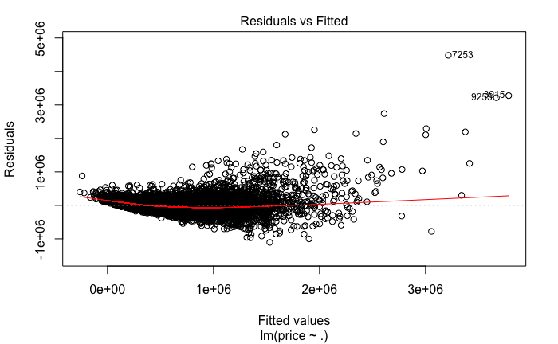

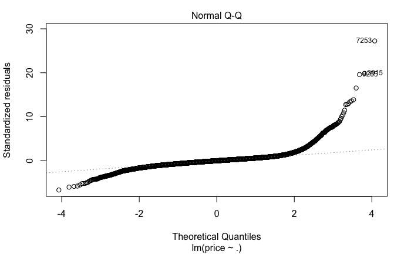

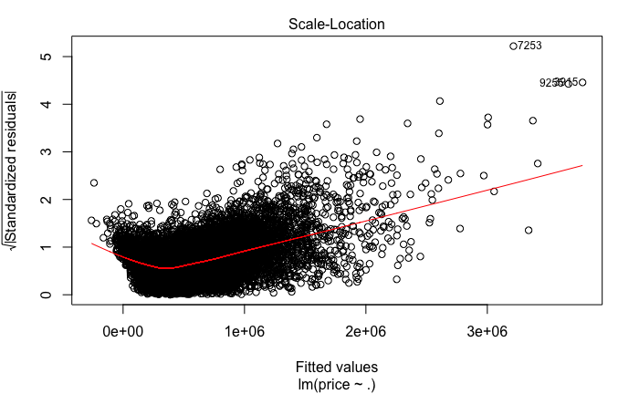

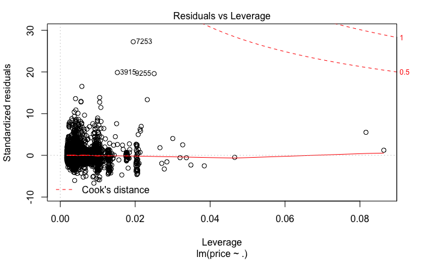

```r
plot(full_model)
```

Looking at **Residuals vs. Fitted**, the line is relatively straight, so a linear regression model is plausible for this dataset. Residuals increase in spread as fitted values increase. This confirms Heteroskedasticity. **Scale-Location** graph also shows this spread.

Looking at **Residuals vs. Leverage**, there are no extreme points present in top right and bottom right corners, and no points passing cook’s distance. So no need to eliminate any values because the model will not change much if done so.

Looking at the **Normal Q-Q** plot, each end of the line has values that rise / fall into extremes, but grand majority of the middle line is straight. So this is a normal distribution with more extreme values than usually seen in normal distributions.